# Project_Low_Code_Notebook_EasyVisa (2)

## Model Building - Original Data

```python
models = []  # Empty list to store all the models

# Appending models into the list
models.append(("Bagging", BaggingClassifier(random_state=1)))
models.append(("Random Forest", RandomForestClassifier(random_state=1, class_weight="balanced")))
models.append(("Adaboost", AdaBoostClassifier(random_state=1)))
models.append(("Gradient Boosting", GradientBoostingClassifier(random_state=1)))
models.append(("XGBoost", XGBClassifier(random_state=1, eval_metric="logloss")))



print("\n" "Training Performance:" "\n")
for name, model in models:
    model.fit(X_train, y_train)
    scores = f1_score(y_train, model.predict(X_train))
    print("{}: {}".format(name, scores))

print("\n" "Validation Performance:" "\n")

for name, model in models:
    model.fit(X_train, y_train)
    scores_val = f1_score(y_val, model.predict(X_val))
    print("{}: {}".format(name, scores_val))
```

```
Training Performance:

Bagging: 0.989150179193873
Random Forest: 1.0
Adaboost: 0.8204269947530306
Gradient Boosting: 0.8291218182658106
XGBoost: 0.8949108348465801

Validation Performance:

Bagging: 0.7736516357206012
Random Forest: 0.8049978941457251
Adaboost: 0.8180081855388813
Gradient Boosting: 0.826637008202419
XGBoost: 0.8104410943606923
```

## Model Building - Oversampled Data

```python
print("Before Oversampling, counts of label 'Certified': {}".format(sum(y_train == 1)))
print("Before Oversampling, counts of label 'Denied': {} \n".format(sum(y_train == 0)))

sm = SMOTE(
    sampling_strategy=1, k_neighbors=5, random_state=1
)  # Synthetic Minority Over Sampling Technique
X_train_over, y_train_over = sm.fit_resample(X_train, y_train)


print("After Oversampling, counts of label 'Certified': {}".format(sum(y_train_over == 1)))
print("After Oversampling, counts of label 'Denied': {} \n".format(sum(y_train_over == 0)))


print("After Oversampling, the shape of train_X: {}".format(X_train_over.shape))
print("After Oversampling, the shape of train_y: {} \n".format(y_train_over.shape))
```

```
Before Oversampling, counts of label 'Certified': 10210
Before Oversampling, counts of label 'Denied': 5078

After Oversampling, counts of label 'Certified': 10210
After Oversampling, counts of label 'Denied': 10210

After Oversampling, the shape of train_X: (20420, 21)
After Oversampling, the shape of train_y: (20420,)
```

```python
models = []  # Empty list to store all the models

# Appending models into the list
models.append(("Bagging", BaggingClassifier(random_state=1)))
models.append(("Random Forest", RandomForestClassifier(random_state=1)))
models.append(("Adaboost", AdaBoostClassifier(random_state=1)))
models.append(("Gradient Boosting", GradientBoostingClassifier(random_state=1)))
models.append(("XGBoost", XGBClassifier(random_state=1, eval_metric="logloss")))


print("\n" "Training Performance:" "\n")
for name, model in models:
    model.fit(X_train_over, y_train_over)
    scores = f1_score(y_train_over, model.predict(X_train_over))
    print("{}: {}".format(name, scores))

print("\n" "Validation Performance:" "\n")

for name, model in models:
    model.fit(X_train_over, y_train_over)
    scores = f1_score(y_val, model.predict(X_val))
    print("{}: {}".format(name, scores))
```

```
Training Performance:

Bagging: 0.9875473741201949
Random Forest: 0.9999510260051913
Adaboost: 0.8005498403689252
Gradient Boosting: 0.8072434234901815
XGBoost: 0.8708686342053813

Validation Performance:

Bagging: 0.7665171898355755
Random Forest: 0.7965442764578834
Adaboost: 0.8195334879279771
Gradient Boosting: 0.8173049645390071
XGBoost: 0.8129304286718201
```

## Model Building - Undersampled Data

```python
rus = RandomUnderSampler(random_state=1)
X_train_un, y_train_un = rus.fit_resample(X_train, y_train)
```

```python
print("Before Under Sampling, counts of label 'Certified': {}".format(sum(y_train == 1)))
print("Before Under Sampling, counts of label 'Denied': {} \n".format(sum(y_train == 0)))

print("After Under Sampling, counts of label 'Certified': {}".format(sum(y_train_un == 1)))
print("After Under Sampling, counts of label 'Denied': {} \n".format(sum(y_train_un == 0)))

print("After Under Sampling, the shape of train_X: {}".format(X_train_un.shape))
print("After Under Sampling, the shape of train_y: {} \n".format(y_train_un.shape))
```

```
Before Under Sampling, counts of label 'Certified': 10210
Before Under Sampling, counts of label 'Denied': 5078

After Under Sampling, counts of label 'Certified': 5078
After Under Sampling, counts of label 'Denied': 5078

After Under Sampling, the shape of train_X: (10156, 21)
After Under Sampling, the shape of train_y: (10156,)
```

```python
models = []  # Empty list to store all the models

# Appending models into the list
models.append(("Bagging", BaggingClassifier(random_state=1)))
models.append(("Random Forest", RandomForestClassifier(random_state=1)))
models.append(("Adaboost", AdaBoostClassifier(random_state=1)))
models.append(("Gradient Boosting", GradientBoostingClassifier(random_state=1)))
models.append(("XGBoost", XGBClassifier(random_state=1, eval_metric="logloss")))


print("\n" "Training Performance:" "\n")
for name, model in models:
    model.fit(X_train_un, y_train_un)
    scores = f1_score(y_train_un, model.predict(X_train_un))
    print("{}: {}".format(name, scores))

print("\n" "Validation Performance:" "\n")

for name, model in models:
    model.fit(X_train_un, y_train_un)
    scores = f1_score(y_val, model.predict(X_val))
    print("{}: {}".format(name, scores))
```

```
Training Performance:

Bagging: 0.9803687095166915
Random Forest: 1.0
Adaboost: 0.7015343047380103
Gradient Boosting: 0.7281441717791411
XGBoost: 0.8720351390922401

Validation Performance:

Bagging: 0.7057046979865772
Random Forest: 0.7417218543046358
Adaboost: 0.765990884802766
Gradient Boosting: 0.776595744680851
XGBoost: 0.7459304181295883
```

# **Model Performance Improvement**

## **Note**

1. Sample parameter grids have been provided to do necessary hyperparameter tuning. These sample grids are expected to provide a balance between model performance improvement and execution time. One can extend/reduce the parameter grid based on execution time and system configuration.
- Please note that if the parameter grid is extended to improve the model performance further, the execution time will increase
2. The models chosen in this notebook are based on test runs. One can update the best models as obtained upon code execution and tune them for best performance.
- For Gradient Boosting:

```
param_grid = {
    "init": [AdaBoostClassifier(random_state=1),DecisionTreeClassifier(random_state=1)],
    "n_estimators": np.arange(50,110,25),
    "learning_rate": [0.01,0.1,0.05],
    "subsample":[0.7,0.9],
    "max_features":[0.5,0.7,1],
}
```

- For Adaboost:

```
param_grid = {
    "n_estimators": np.arange(50,110,25),
    "learning_rate": [0.01,0.1,0.05],
    "base_estimator": [
        DecisionTreeClassifier(max_depth=2, random_state=1),
        DecisionTreeClassifier(max_depth=3, random_state=1),
    ],
}
```

- For Bagging Classifier:

```
param_grid = {
    'max_samples': [0.8,0.9,1],
    'max_features': [0.7,0.8,0.9],
    'n_estimators' : [30,50,70],
}
```

- For Random Forest:

```
param_grid = {
    "n_estimators": [50,110,25],
    "min_samples_leaf": np.arange(1, 4),
    "max_features": [np.arange(0.3, 0.6, 0.1),'sqrt'],
    "max_samples": np.arange(0.4, 0.7, 0.1)
}
```

- For Decision Trees:

```
param_grid = {
    'max_depth': np.arange(2,6),
    'min_samples_leaf': [1, 4, 7],
    'max_leaf_nodes' : [10, 15],
    'min_impurity_decrease': [0.0001,0.001]
}
```

- For XGBoost:

```
param_grid={'n_estimators':np.arange(50,110,25),
            'scale_pos_weight':[1,2,5],
            'learning_rate':[0.01,0.1,0.05],
            'gamma':[1,3],
            'subsample':[0.7,0.9]
}
```

## Hyperparameter Tuning - Random Forest

```python
%%time
# Choose the type of classifier.
rf_tuned = RandomForestClassifier(random_state=1, oob_score=True, bootstrap=True)

parameters = {
    "max_depth": list(np.arange(5, 15, 5)),
    "max_features": ["sqrt", "log2"],
    "min_samples_split": [3, 5, 7],
    "n_estimators": np.arange(10, 40, 10),
}

# Type of scoring used to compare parameter combinations
acc_scorer = metrics.make_scorer(metrics.f1_score)

# Run the grid search
# Changed n_jobs from -1 to 1 to potentially avoid multiprocessing issues
grid_obj = GridSearchCV(rf_tuned, parameters, scoring=acc_scorer, cv=5, n_jobs=1)
grid_obj = grid_obj.fit(X_train_over, y_train_over)

# Set the clf to the best combination of parameters
rf_tuned = grid_obj.best_estimator_

# Fit the best algorithm to the data.
rf_tuned.fit(X_train, y_train)
```

```
CPU times: user 39.1 s, sys: 81.3 ms, total: 39.2 s
Wall time: 40.3 s
```

```
RandomForestClassifier(max_depth=np.int64(10), min_samples_split=5,
                       n_estimators=np.int64(30), oob_score=True,
                       random_state=1)
```

### Checking model performance on training set

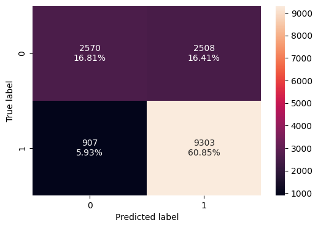

```python
confusion_matrix_sklearn(rf_tuned, X_train, y_train)
```

```python
rf_tuned_model_train_perf = model_performance_classification_sklearn(
    rf_tuned, X_train, y_train
)
rf_tuned_model_train_perf
```

|  | Accuracy | Recall | Precision | F1 |
| --- | --- | --- | --- | --- |
| 0 | 0.776622 | 0.911166 | 0.787656 | 0.844921 |

### Checking model performance on validation set

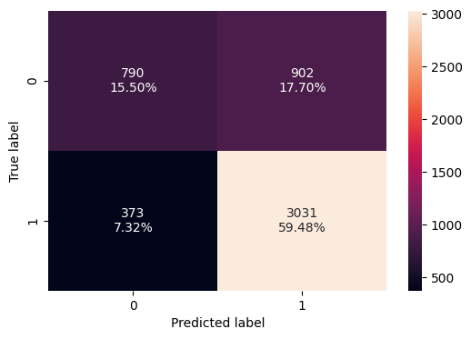

```python
confusion_matrix_sklearn(rf_tuned, X_val, y_val)
```

```python
rf_tuned_model_val_perf = model_performance_classification_sklearn(
    rf_tuned, X_val, y_val
)
rf_tuned_model_val_perf
```

|  | Accuracy | Recall | Precision | F1 |
| --- | --- | --- | --- | --- |
| 0 | 0.749804 | 0.890423 | 0.770659 | 0.826223 |

## Hyperparameter Tuning - AdaBoost Classifier

```python
%%time
# Choose the type of classifier.
abc_tuned = AdaBoostClassifier(random_state=1)

# Grid of parameters to choose from
parameters = {
    # Let's try different max_depth for base_estimator
    "estimator": [
        DecisionTreeClassifier(max_depth=2, random_state=1),
        DecisionTreeClassifier(max_depth=3, random_state=1),
    ],
    "n_estimators": np.arange(50,110,25),
    "learning_rate": np.arange(0.01,0.1,0.05),
}

# Type of scoring used to compare parameter  combinations
acc_scorer = metrics.make_scorer(metrics.f1_score)

# Run the grid search
grid_obj = GridSearchCV(abc_tuned, parameters, scoring=acc_scorer, cv=5)
grid_obj = grid_obj.fit(X_train, y_train)

# Set the clf to the best combination of parameters
abc_tuned = grid_obj.best_estimator_

# Fit the best algorithm to the data.
abc_tuned.fit(X_train, y_train)
```

```
CPU times: user 1min 23s, sys: 127 ms, total: 1min 23s
Wall time: 1min 24s
```

```
AdaBoostClassifier(estimator=DecisionTreeClassifier(max_depth=3,
                                                    random_state=1),
                   learning_rate=np.float64(0.060000000000000005),
                   n_estimators=np.int64(100), random_state=1)
```

### Checking model performance on training set

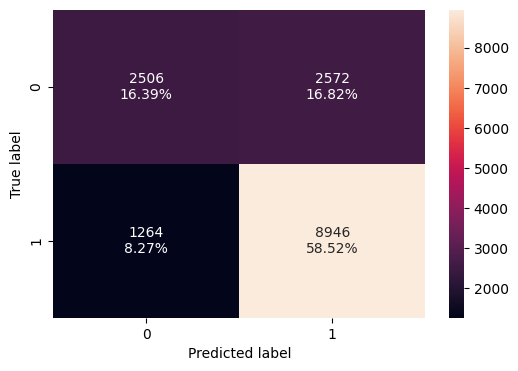

```python
confusion_matrix_sklearn(abc_tuned, X_train, y_train)
```

```python
abc_tuned_model_train_perf = model_performance_classification_sklearn(abc_tuned, X_train, y_train)  ## Complete the code to get the perfromance metrics for the Adaboost Classifier on the training set
abc_tuned_model_train_perf
```

|  | Accuracy | Recall | Precision | F1 |
| --- | --- | --- | --- | --- |
| 0 | 0.749084 | 0.8762 | 0.776697 | 0.823454 |

### Checking model performance on validation set

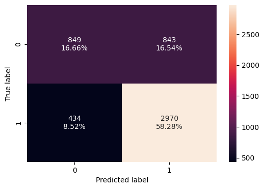

```python
confusion_matrix_sklearn(abc_tuned, X_val, y_val)  ## Complete the code to plot the confusion matrix for the Adaboost Classifier on the validation set
```

```python
abc_tuned_model_val_perf = model_performance_classification_sklearn(abc_tuned, X_val, y_val)  ## Complete the code to get the perfromance metrics for the Adaboost Classifier on the validation set
abc_tuned_model_val_perf
```

|  | Accuracy | Recall | Precision | F1 |
| --- | --- | --- | --- | --- |
| 0 | 0.749411 | 0.872503 | 0.778914 | 0.823057 |

## Hyperparameter Tuning - Gradient Boosting Classifier

```python
%%time
# Choose the type of classifier.
gbc_tuned = GradientBoostingClassifier(
    init=AdaBoostClassifier(random_state=1), random_state=1
)

# Grid of parameters to choose from
parameters = {
    "n_estimators": np.arange(50,110,25),
    "subsample": [0.7,0.9],
    "max_features": [0.7, 0.8, 0.9, 1],
    "learning_rate": [0.01,0.1,0.05],
}

# Type of scoring used to compare parameter combinations
acc_scorer = metrics.make_scorer(metrics.f1_score)

# Run the grid search
grid_obj = GridSearchCV(gbc_tuned, parameters, scoring=acc_scorer, cv=5)  ## Complete the code to define the grid search object
grid_obj = grid_obj.fit(X_train, y_train)

# Set the clf to the best combination of parameters
gbc_tuned = grid_obj.best_estimator_

# Fit the best algorithm to the data.
gbc_tuned.fit(X_train, y_train)
```

```
CPU times: user 7min 27s, sys: 987 ms, total: 7min 28s
Wall time: 7min 34s
```

```
GradientBoostingClassifier(init=AdaBoostClassifier(random_state=1),
                           learning_rate=0.05, max_features=0.7,
                           n_estimators=np.int64(50), random_state=1,
                           subsample=0.7)
```

### Checking model performance on training set

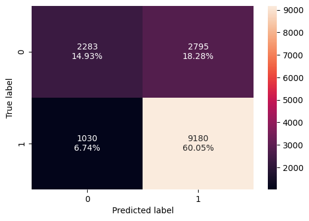

```python
confusion_matrix_sklearn(gbc_tuned, X_train, y_train)  ## Complete the code to plot the confusion matrix for the Gradient Boosting Classifier on the training set
```

```python
gbc_tuned_model_train_perf = model_performance_classification_sklearn(gbc_tuned, X_train, y_train)  ## Complete the code to get the perfromance metrics for the Gradient Boosting Classifier on the training set
gbc_tuned_model_train_perf
```

|  | Accuracy | Recall | Precision | F1 |
| --- | --- | --- | --- | --- |
| 0 | 0.749804 | 0.899119 | 0.766597 | 0.827586 |

### Checking model performance on validation set

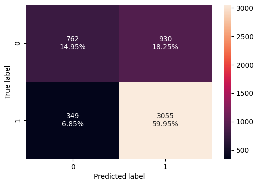

```python
confusion_matrix_sklearn(gbc_tuned, X_val, y_val)  ## Complete the code to plot the confusion matrix for the Gradient Boosting Classifier on the validation set
```

```python
gbc_tuned_model_val_perf = model_performance_classification_sklearn(gbc_tuned, X_val, y_val)  ## Complete the code to get the perfromance metrics for the Gradient Boosting Classifier on the validation set
gbc_tuned_model_val_perf
```

|  | Accuracy | Recall | Precision | F1 |
| --- | --- | --- | --- | --- |
| 0 | 0.749019 | 0.897474 | 0.766625 | 0.826905 |

## Hyperparameter Tuning - XGBoost Classifier

```python
%%time
# Choose the type of classifier.
xgb_tuned = XGBClassifier(random_state=1, eval_metric="logloss")

# Grid of parameters to choose from
parameters = {
    "n_estimators": np.arange(50,110,25),
    "scale_pos_weight": [1,2,5],
    "subsample": [0.9, 1],
    "learning_rate": [0.01,0.1,0.05],
    "gamma": [1,3]
}

# Type of scoring used to compare parameter combinations
acc_scorer = metrics.make_scorer(metrics.f1_score)

# Run the grid search
grid_obj = GridSearchCV(xgb_tuned,parameters, scoring=acc_scorer, cv=5)
grid_obj = grid_obj.fit(X_train_over, y_train_over)

# Set the clf to the best combination of parameters
xgb_tuned = grid_obj.best_estimator_

# Fit the best algorithm to the data.
xgb_tuned.fit(X_train, y_train)
```

```
CPU times: user 3min 49s, sys: 1.71 s, total: 3min 51s
Wall time: 2min 32s
```

```
XGBClassifier(base_score=None, booster=None, callbacks=None,
              colsample_bylevel=None, colsample_bynode=None,
              colsample_bytree=None, device=None, early_stopping_rounds=None,
              enable_categorical=False, eval_metric='logloss',
              feature_types=None, gamma=1, grow_policy=None,
              importance_type=None, interaction_constraints=None,
              learning_rate=0.1, max_bin=None, max_cat_threshold=None,
              max_cat_to_onehot=None, max_delta_step=None, max_depth=None,
              max_leaves=None, min_child_weight=None, missing=nan,
              monotone_constraints=None, multi_strategy=None,
              n_estimators=np.int64(100), n_jobs=None, num_parallel_tree=None,
              random_state=1, ...)
```

### Checking model performance on training set

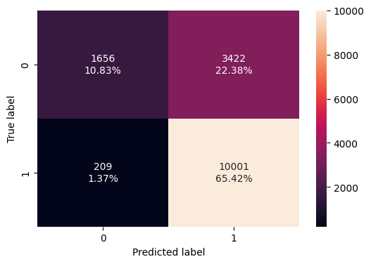

```python
confusion_matrix_sklearn(xgb_tuned, X_train, y_train)  ## Complete the code to plot the confusion matrix for the XGBoost Classifier on the training set
```

```python
xgb_tuned_model_train_perf = model_performance_classification_sklearn(xgb_tuned, X_train, y_train)  ## Complete the code to get the perfromance metrics for the XGBoost Classifier on the training set
xgb_tuned_model_train_perf
```

|  | Accuracy | Recall | Precision | F1 |
| --- | --- | --- | --- | --- |
| 0 | 0.762493 | 0.97953 | 0.745064 | 0.846359 |

### Checking model performance on validation set

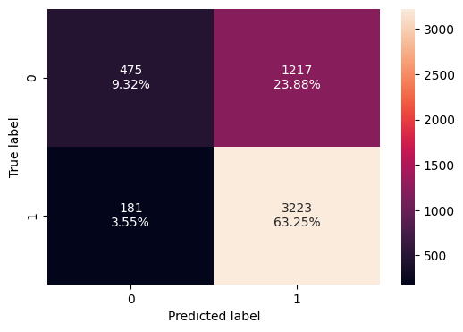

```python
confusion_matrix_sklearn(xgb_tuned, X_val, y_val)  ## Complete the code to plot the confusion matrix for the XGBoost Classifier on the validation set
```

```python
xgb_tuned_model_val_perf = model_performance_classification_sklearn(xgb_tuned, X_val, y_val)  ## Complete the code to get the perfromance metrics for the XGBoost Classifier on the validation set
xgb_tuned_model_val_perf
```

|  | Accuracy | Recall | Precision | F1 |
| --- | --- | --- | --- | --- |
| 0 | 0.725667 | 0.946827 | 0.725901 | 0.821775 |

# **Model Comparison and Final Model Selection**

## Comparing all models

```python
# training performance comparison

models_train_comp_df = pd.concat(
    [
        rf_tuned_model_train_perf.T,
        abc_tuned_model_train_perf.T,
        gbc_tuned_model_train_perf.T,
        xgb_tuned_model_train_perf.T,
    ],
    axis=1,
)
models_train_comp_df.columns = [
    "Tuned Random Forest",
    "Tuned Adaboost Classifier",
    "Tuned Gradient Boost Classifier",
    "XGBoost Classifier Tuned",
]
print("Training performance comparison:")
models_train_comp_df
```

```
Training performance comparison:
```

|  | Tuned Random Forest | Tuned Adaboost Classifier | Tuned Gradient Boost Classifier | XGBoost Classifier Tuned |
| --- | --- | --- | --- | --- |
| Accuracy | 0.776622 | 0.749084 | 0.749804 | 0.762493 |
| Recall | 0.911166 | 0.876200 | 0.899119 | 0.979530 |
| Precision | 0.787656 | 0.776697 | 0.766597 | 0.745064 |
| F1 | 0.844921 | 0.823454 | 0.827586 | 0.846359 |

```python
# validation performance comparison

models_val_comp_df = pd.concat(
    [
        rf_tuned_model_val_perf.T,
        abc_tuned_model_val_perf.T,
        gbc_tuned_model_val_perf.T,
        xgb_tuned_model_val_perf.T,
    ],
    axis=1,
)

models_val_comp_df.columns = [
    "Tuned Random Forest",
    "Tuned Adaboost Classifier",
    "Tuned Gradient Boost Classifier",
    "XGBoost Classifier Tuned",
]
print("Validation performance comparison:")
models_val_comp_df
```

```
Validation performance comparison:
```

|  | Tuned Random Forest | Tuned Adaboost Classifier | Tuned Gradient Boost Classifier | XGBoost Classifier Tuned |
| --- | --- | --- | --- | --- |
| Accuracy | 0.749804 | 0.749411 | 0.749019 | 0.725667 |
| Recall | 0.890423 | 0.872503 | 0.897474 | 0.946827 |
| Precision | 0.770659 | 0.778914 | 0.766625 | 0.725901 |
| F1 | 0.826223 | 0.823057 | 0.826905 | 0.821775 |

## Important features of the final model

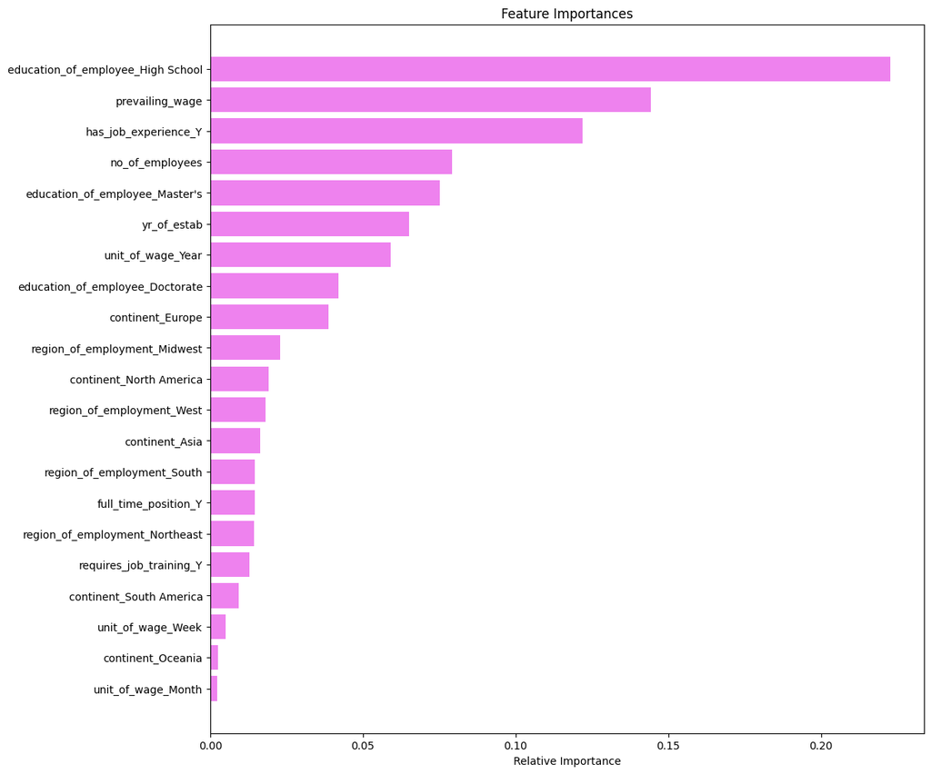

```python
feature_names = X_train.columns
importances = rf_tuned.feature_importances_  ## Complete the code to get the feature importances of the best model
indices = np.argsort(importances)

plt.figure(figsize=(12, 12))
plt.title("Feature Importances")
plt.barh(range(len(indices)), importances[indices], color="violet", align="center")
plt.yticks(range(len(indices)), [feature_names[i] for i in indices])
plt.xlabel("Relative Importance")
plt.show()
```

# **Actionable Insights and Recommendations**

For visa to have a better chance to be approved this are the following recommendations that can be applied:

1. Prioritize education: focus on highly educated applicants to improve approval odds. This means to have a master's degree or above.
2. Highlight experience: this means that having work experience can increase the odds.
3. Target higher wages: this relates to consider offering competitive wages to signal high skill levels and meet regulatory expectations.
4. Leverage large employers: partner with established firms with higer approval credibility.
5. Select Midwest/South for filing: If feasible, use company offices in high-approval regions like the Midwest.
6. Consider geographic trends like being aware of continent-based approval patterns to prepare stronger documentation for underrepresented regions.